# Free Unlimited Private Git Space with Microsoft Visual Studio Online

David Liu

October 26, 2015

## Overview

[GitHub](https://github.com/) gives you unlimited *public* space for free. What if you have a private project, you don’t really want to or it is not an option for you to put that source code in a public GitHub? I am going to tell you that you can have unlimited *private* Git space too. Except the space is going to come from the Microsoft, and not from the GitHub.com.

You might ask: *Do I have to use Visual Studio to get free unlimited private Git space?* **NO!**

Here are the steps:

1. Sign up for a free [Visual Studio Online](https://www.visualstudio.com) account.
- Click on the green button under the “Visual Studio Online” text.

[figure not shown]

- You will be directed to a Microsoft Account Login area. If you already have a hotmail or Microsoft Live account you can login there, or you can create a new account by clicking the “Sign Up Now” link at the bottom-right corner of the screen:

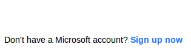

- If you are creating a new account, you will be redirected to signup.live.com:

[figure not shown]

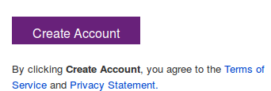

- On the next screen, you will prompted to create your first project. This is where you create your first Git repository. Be sure to check the **Git** option in the repository type:

[figure not shown]

- Click the **Create Project** button to complete the Git Repository Creation. You should see a new repository being created.

[figure not shown]

- **Create New Repository**: Click “New Repository” to create a new repository, you can click on the top-left corner “Project1” (or your Project Name) to see a dropdown menu being displayed:

[figure not shown]

- Once your new repository is created, a screen is displayed allowing you to generate git credentials.

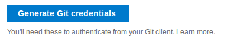

- Alternatively, you can click on the “Step-by-Step” link at the bottom of the page to get a set of commands to clone or push to the Git repository you have just created.

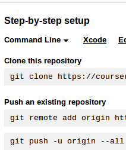